# Discount Rates and Environmental Policy

November 2025

## The Time Value Problem

**Key Question:** How do we compare costs today with benefits decades or centuries from now?

- Clean energy infrastructure: costs now, benefits for 50+ years
- Climate mitigation: costs now, benefits for centuries
- Toxic waste cleanup: costs now, prevents harm for generations

## Why Discounting Matters

**Environmental policies involve intertemporal trade-offs:**

- Initial investment costs (present)
- Operating and maintenance costs (ongoing)
- Environmental benefits (long-term)
- Health improvements (delayed)

**The discount rate determines how we value the future**

## Future Value: The Basics

**Starting point:** How does money grow over time?

\[FV = PV \times (1 + r)^t\]

Where:

- \(FV\) = Future Value (what you’ll have)
- \(PV\) = Present Value (what you start with)
- \(r\) = interest rate (as decimal, e.g., 0.05 = 5%)
- \(t\) = time periods (usually years)

## Future Value: Step-by-Step

**Example:** $100 invested at 5% annual rate

**Year 1:** \[FV_1 = 100 \times (1 + 0.05)^1 = 100 \times 1.05 = \$105\]

**Year 2:** \[FV_2 = 100 \times (1 + 0.05)^2 = 100 \times 1.1025 = \$110.25\]

**Year 3:** \[FV_3 = 100 \times (1 + 0.05)^3 = 100 \times 1.157625 = \$115.76\]

Notice: Each year compounds on the previous total

## Future Value Over 25 Years

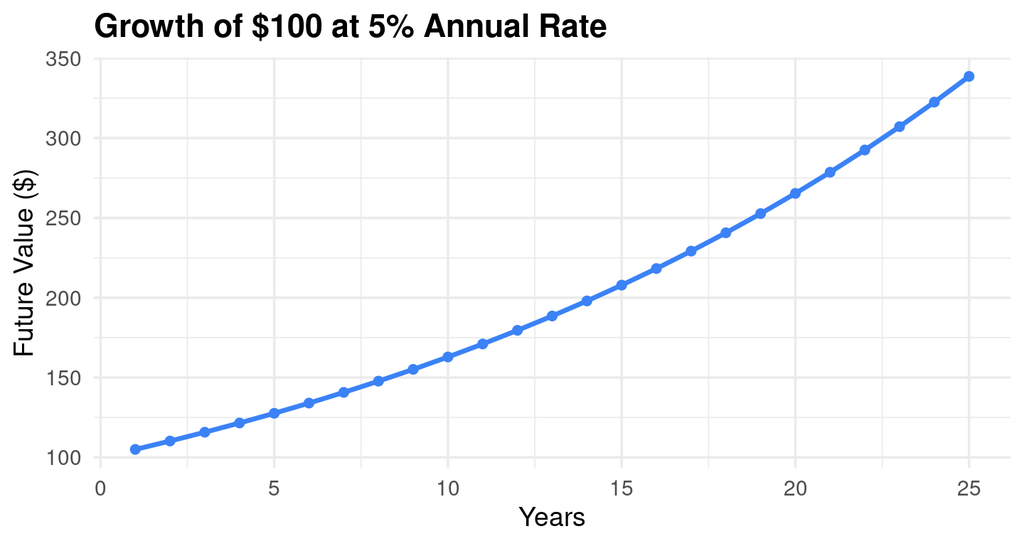

After 25 years: **$338.64** (more than 3× the original investment)

## Present Value: The Reverse Problem

**Question:** What is $100 of future benefit worth today?

**Rearrange the formula:** \[PV = \frac{FV}{(1 + r)^t}\]

**This is discounting:** Converting future values to present-day equivalents

## Present Value: Step-by-Step

**Question:** What is $100 received in 3 years worth today at 5% discount rate?

**Step 1:** Calculate the discount factor \[(1 + 0.05)^3 = 1.157625\]

**Step 2:** Divide future value by discount factor \[PV = \frac{100}{1.157625} = \$86.38\]

**Interpretation:** $86.38 today is equivalent to $100 in 3 years (at 5% rate)

## Present Value Example: 25 Years

**How much is $100 of benefit in 25 years worth today?**

At 5% discount rate: \[PV = \frac{100}{(1 + 0.05)^{25}} = \frac{100}{3.386} = \$29.53\]

At 1% discount rate: \[PV = \frac{100}{(1 + 0.01)^{25}} = \frac{100}{1.282} = \$78.00\]

**The choice of discount rate dramatically affects present values!**

## The Discount Rate’s Impact

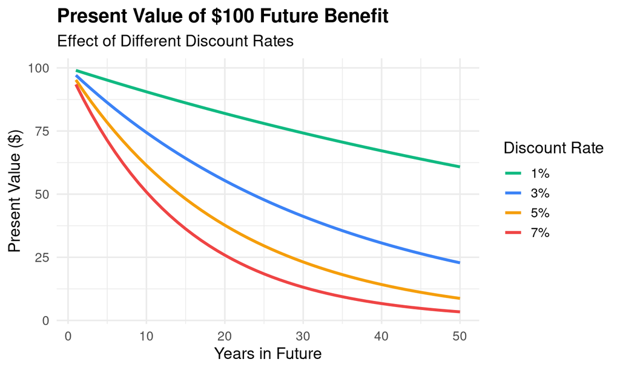

## Extreme Case: 100 Years

**Present value of $100 benefit in 100 years:**

At 1% discount rate: \[PV = \frac{100}{(1.01)^{100}} = \$37.00\]

At 5% discount rate: \[PV = \frac{100}{(1.05)^{100}} = \$0.76\]

**At 5%, benefits a century from now are essentially worthless today!**

## Long-term Environmental Damages

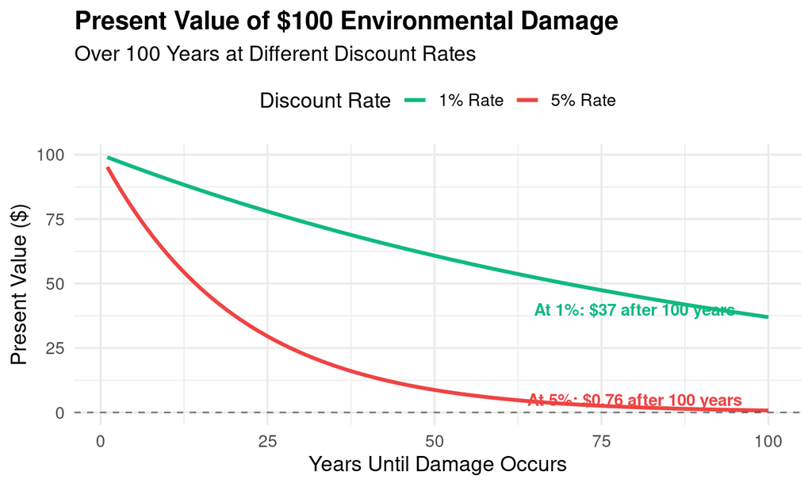

## The Climate Change Challenge

**Why discount rates matter for climate policy:**

1. **Long time horizons:** GHG emissions cause damages centuries into future
2. **Irreversibility:** Many climate impacts cannot be undone
3. **Intergenerational equity:** High discount rates devalue future generations
4. **Catastrophic risks:** Possibility of severe, irreversible damages

**The Stern Review (2006):** Used ~1.4% rate → aggressive action warranted

**Traditional economics:** Often uses 3-7% → less urgent action

## Components of the Discount Rate

**Social Discount Rate = Pure Time Preference + Growth Effect**

\[r = \rho + \eta \times g\]

Where:

- \(\rho\) = pure time preference (impatience)
- \(\eta\) = elasticity of marginal utility (inequality aversion)
- \(g\) = expected consumption growth rate

**Each component is ethically debatable**

## Pure Time Preference (ρ)

**Question:** Should we value people in the future less than people today?

**Ethical arguments:**

- \(\rho = 0\): Future people matter equally (Stern Review approach)
- \(\rho > 0\): We naturally prefer present over future (Nordhaus approach)

**Example impact:** - If \(\rho = 0\) and other components sum to 1.4%, total rate = 1.4% - If \(\rho = 1.5\%\) and other components sum to 1.4%, total rate = 2.9%

## Growth Effect (η × g)

**Question:** Will future generations be richer than us?

**Logic:** If future is richer, they can better afford costs, so we discount less

**Consumption growth (g):** - Optimistic: \(g = 2\%\) per year - Pessimistic: \(g = 1\%\) per year

**Inequality aversion (η):** - High \(\eta = 2\): Strong preference for helping poorer people - Low \(\eta = 1\): Weak preference for redistribution

## Example Calculation

**Calculate social discount rate:**

Assumptions: - Pure time preference: \(\rho = 0.5\%\) - Inequality aversion: \(\eta = 1.5\) - Growth rate: \(g = 2\%\)

\[r = 0.005 + (1.5 \times 0.02) = 0.005 + 0.03 = 0.035\]

**Result: 3.5% social discount rate**

## Real-World Examples

**U.S. Government (OMB Circular A-4):** - Base case: 3% and 7% - Lower rates for intergenerational projects

**UK Green Book:** - 3.5% declining to 3% after 30 years - Further declines for longer horizons

**France:** - 4% for near-term - Declining scale for climate projects

## Policy Implications

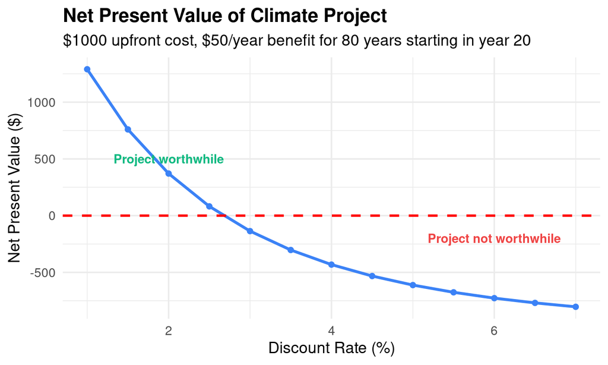

## Ethical Considerations

**The discounting debate raises fundamental questions:**

1. **Intergenerational justice:** Do we owe duties to future generations?
2. **Uncertainty:** What if damages are worse than expected?
3. **Irreversibility:** Should we discount irreplaceable natural capital?
4. **Catastrophic risk:** How to value low-probability, high-impact events?

**No purely technical answer—requires ethical and political judgment**

## Alternative Approaches

**Beyond traditional discounting:**

1. **Declining discount rates:** Lower rates for distant future (UK approach)
2. **Dual discounting:** Different rates for different types of impacts
3. **Precautionary principle:** Conservative approach under uncertainty
4. **Safe minimum standards:** Protect critical thresholds regardless of NPV
5. **Sustainability constraints:** Maintain natural capital stocks

## Summary: Key Takeaways

1. **Discount rates convert future values to present equivalents**
   - Higher rates → future matters less
   - Lower rates → future matters more
2. **Formula:** \(PV = \frac{FV}{(1 + r)^t}\)
3. **For long-term environmental problems:**
   - Rate choice is ethically loaded
   - Small rate differences = huge outcome differences
   - Climate change most sensitive to this choice
4. **Policy challenge:** Balance economic efficiency with intergenerational equity

## Discussion Questions

1. Is it ethical to use positive pure time preference rates for climate policy?
2. If future generations are expected to be wealthier, should we do less for them today?
3. How should we account for catastrophic but uncertain climate risks?
4. Should discount rates differ for different types of environmental damages?
5. What role should economic efficiency play versus ethical duties to the future?

## Further Resources

**Key Papers:** - Stern, N. (2007). *The Economics of Climate Change: The Stern Review* - Nordhaus, W. (2007). “A Review of the Stern Review” - Weitzman, M. (2007). “A Review of the Stern Review’s Economics”

**Government Guidance:** - OMB Circular A-4 (U.S.) - UK Green Book - EPA Guidelines for Economic Analysis

## The Social Cost of Carbon (SCC)

**Definition:**  
The **Social Cost of Carbon (SCC)** is the **monetary value of the damages caused by emitting one additional ton of CO₂** into the atmosphere.

It represents the **present value of future climate damages**, including: - Health impacts - Agricultural losses - Sea level rise and property damages - Ecosystem degradation

**Key idea:** The SCC depends *heavily* on the **discount rate** — small changes in rate = large changes in SCC.

## Why Discount Rates Matter for SCC

Since the SCC sums up damages occurring over centuries, the **discount rate** dramatically alters the estimated cost.

| Discount Rate | Estimated SCC (2020$ per ton CO₂) | Source |
| --- | --- | --- |
| 1% | ~$190 | EPA (2023) |
| 2% | ~$120 | EPA (2023) |
| 3% | ~$56 | EPA (2023) |
| 5% | ~$14 | EPA (2010) |

**Interpretation:** - A **lower discount rate** (1–2%) implies **high future damages** are given more weight → stronger climate action justified. - A **higher rate** (3–5%) discounts those damages → weaker incentives for mitigation.

## SCC and Policy Applications

**Uses of SCC:** 1. **Regulatory analysis:** Determines cost-benefit of emissions rules (e.g., fuel efficiency, power plant standards) 2. **Carbon pricing:** Guides carbon taxes or cap-and-trade allowance prices 3. **Public investment:** Evaluates long-term infrastructure resilience 4. **Corporate strategy:** Used by firms to assess climate risk exposure

**Example:**  
If the SCC = $120/ton CO₂, a policy that cuts 10 million tons of CO₂ avoids **$1.2 billion in future climate damages** (in today’s dollars).

## The Discount Rate–SCC Relationship

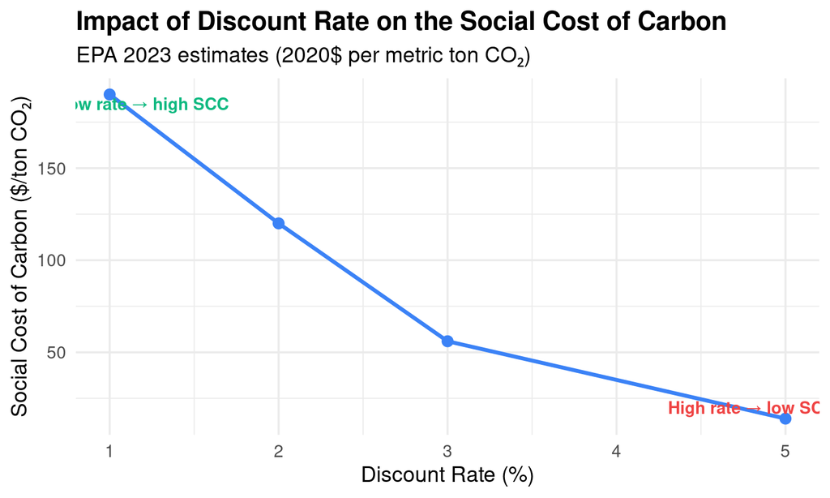

Ethical and Policy Implications of SCC

Equity across generations: A higher SCC (from low discounting) values future lives and well-being more equally.

Precaution under uncertainty: Climate damages are uncertain but potentially catastrophic — justifying low discount rates.

Global coordination: The SCC reflects global damages, so ideally, it should be a global value, not country-specific.

Policy sensitivity: Even modest changes in discount rate can shift climate policy cost-benefit outcomes by billions of dollars.

Summary Connection

The Social Cost of Carbon = Present Value of all future damages from 1 ton of CO₂

Discount rates are the critical link between economics and ethics in SCC estimation.

Policy takeaway: Choosing a discount rate is not just an economic decision — it’s a moral statement about how much we value the future.

Updated Key Takeaways

Discount rate choice determines the urgency of climate action.

Social Cost of Carbon (SCC) operationalizes discounting in climate economics.

Lower discount rates → higher SCC → stronger climate policy justification.

Ethical considerations are inseparable from the economics of discounting.

Discussion Extension

Should the SCC use the same discount rate as traditional investments?

Is it ethical to apply national (vs. global) SCC estimates?

Should uncertainty in climate impacts justify a declining discount rate over time?

## Simulating the Social Cost of Carbon Over Time

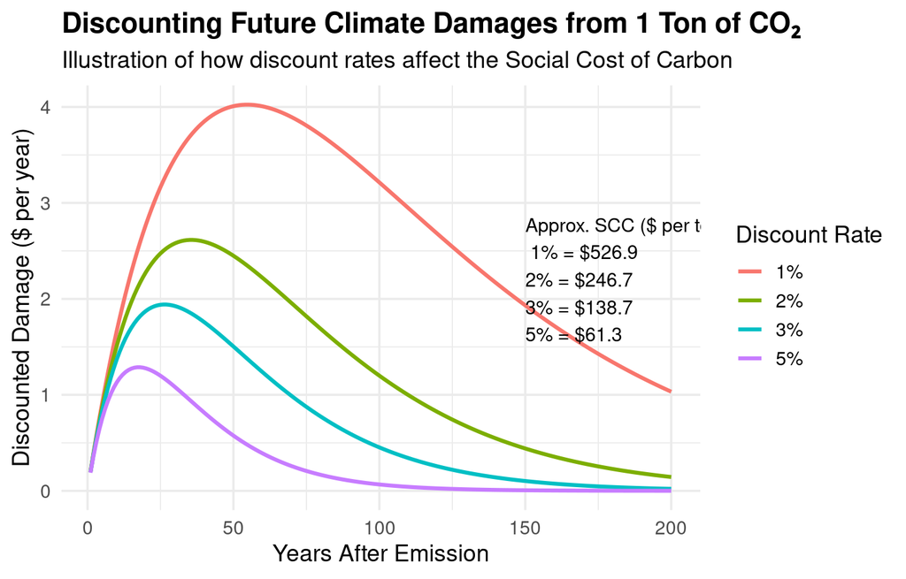

## Cumulative Social Cost of Carbon Over Time

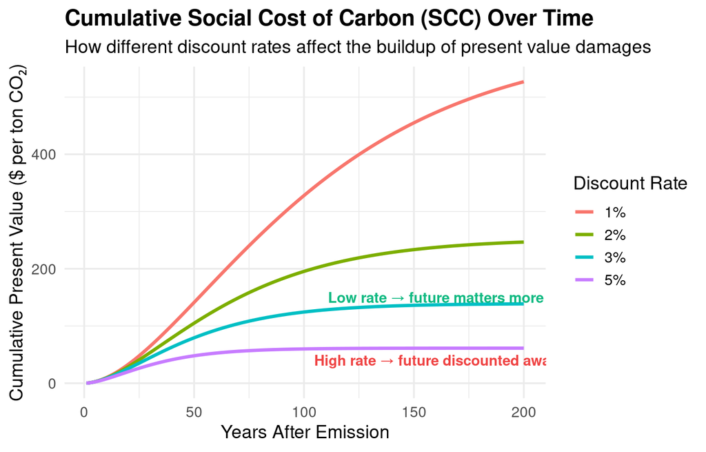